# Module R’Stat1 : Rappels (1/4)

francois.rebaudo@ird.fr

Novembre 2019 ; IRD-Montpellier-France CC BY-NC-ND 3.0

# Rappels : environnement de travail

## R et EDI

Les principaux EDI et éditeurs de texte pour R :

[figure not shown]

# Rappels : la notion d’objet

## un objet ?

```r
monObjet <- 5
monObjet = 5
5 -> monObjet
print(monObjet)
```

```
## [1] 5
```

```r
monObjet <- 15
print(monObjet)
```

```
## [1] 15
```

Dans ce cours nous utiliserons toujours la forme `<-` par souci de consistance et aussi parce que c’est la forme la plus répandue.

## (parenthèse sur le style)

- le style *lowerCamelCase*
- les espaces
- l’indentation

## un objet ?

```r
monObjet + 10
```

```
## [1] 25
```

```r
monObjet * pi
```

```
## [1] 47.12389
```

## un objet ?

FONCTION pour lister les objets : `ls()`

```r
ls()
```

```
## [1] "monObjet"
```

```r
ls(pattern = "^m[a-zA-Z]*t$") # expression régulière
```

```
## [1] "monObjet"
```

```r
ls(pattern = "^m[a-zA-Z]*x$")
```

```
## character(0)
```

## un objet ?

```r
monNomDeVariable <- "monObjet"
assign(monNomDeVariable, value = 5)
print(monObjet)
```

```
## [1] 5
```

## un objet ?

```r
ls(pattern = "^spp[A-Z]$")
```

```
## character(0)
```

```r
mesEspeces <- c("sppA", "sppB", "sppC")
mesDonnes  <- c(5, 7, 8)
for(i in seq_along(mesEspeces)){
  assign(
    mesEspeces[i],
    value = mesDonnes[i]
  )
}
ls(pattern = "^spp[A-Z]$")
```

```
## [1] "sppA" "sppB" "sppC"
```

# Rappels : le répertoire de travail

## Mais où suis-je ?

```r
getwd()
```

```
## [1] "D:/00__EN_COURS/FORMATION/CURSOS_DE_R_2019_IRD"
```

## Définir son répertoire de travail

```r
myWD <- "./"
setwd(myWD)
getwd()
```

```
## [1] "D:/00__EN_COURS/FORMATION/CURSOS_DE_R_2019_IRD"
```

## Lister les fichiers

```r
list.files()
```

```
##  [1] "_output.yaml"               "00_avantDeVenir.R"
##  [3] "00_buildPrez.R"             "ADMIN"
##  [5] "ARCHIVES"                   "barplot.pdf"
##  [7] "biblio_LM_GLM"              "CURSOS_DE_R_2019_IRD.Rproj"
##  [9] "DATA"                       "dependent_HTML_libraries"
## [11] "inkscape.mp4"               "logoGimp.png"
## [13] "logoInkscape.png"           "multplot.pdf"
## [15] "multplot.png"               "R00_links.html"
## [17] "R00_links.Rmd"              "R010_intro.html"
## [19] "R010_intro.Rmd"             "R011_intro.html"
## [21] "R011_intro.Rmd"             "R012_intro.html"
## [23] "R012_intro.Rmd"             "R013_intro.html"
## [25] "R013_intro.Rmd"             "R014_intro.html"
## [27] "R014_intro.Rmd"             "R015_intro_TD01.html"
## [29] "R015_intro_TD01.Rmd"        "R016_intro_TD02.html"
```

[output cut: 16 more lines]

## Lister les fichiers

```r
list.files(pattern=".*\\.[rR]$")
```

```
## [1] "00_avantDeVenir.R" "00_buildPrez.R"
```

```r
list.files(pattern=".*\\.([rR]md)$")
```

```
##  [1] "R00_links.Rmd"             "R010_intro.Rmd"
##  [3] "R011_intro.Rmd"            "R012_intro.Rmd"
##  [5] "R013_intro.Rmd"            "R014_intro.Rmd"
##  [7] "R015_intro_TD01.Rmd"       "R016_intro_TD02.Rmd"
##  [9] "R021_statsDescrp.Rmd"      "R031_statsSimple.Rmd"
## [11] "R032_statsSimple_TD03.Rmd" "R033_statsSimple_TD04.Rmd"
## [13] "R034_statsSimple_TD05.Rmd" "R041_modLin.Rmd"
## [15] "R051_regLin.Rmd"           "R052_regLin_TD06.Rmd"
## [17] "R053_regLinMult.Rmd"       "R054_regLin_TD07.Rmd"
## [19] "R055_modLin.Rmd"           "R061_ANCOVA.Rmd"
## [21] "R071_ts.Rmd"               "R081_glm.Rmd"
```

## Lister les fichiers

```r
list.files(path = "./DATA", pattern=".*\\.(csv)$")
```

```
## [1] "bdd.csv"         "bddSept2019.csv" "dump.csv"        "patronymes.csv"
## [5] "Prenoms.csv"
```

## Lire un fichier

```r
read.table("Prenoms.csv", header = TRUE, sep = ";", dec = ".")
```

```
## Error in file(file, "rt"): impossible d'ouvrir la connexion
```

## Lire un fichier

```r
bdd <- read.table("./DATA/Prenoms.csv", header = TRUE, sep = ";", dec = ".")
head(bdd)
```

```
##   X01_prenom X02_genre      X03_langage X04_frequence
## 1    aaliyah         f english (modern)             0
## 2     aapeli         m          finnish             0
## 3       aapo         m          finnish             0
## 4      aaren       m,f          english             0
## 5      aarne         m          finnish             0
## 6      aarón         m          spanish             0
```

## Lire un fichier

```r
# setwd("./DATA")
# bdd <- read.table("Prenoms.csv", header = TRUE, sep = ";", dec = ".")
head(bdd)
```

```
##   X01_prenom X02_genre      X03_langage X04_frequence
## 1    aaliyah         f english (modern)             0
## 2     aapeli         m          finnish             0
## 3       aapo         m          finnish             0
## 4      aaren       m,f          english             0
## 5      aarne         m          finnish             0
## 6      aarón         m          spanish             0
```

## Lire un fichier

- csv
- `header` nom des colonnes
- pas de chiffre en début de nom de colonne
- `spe` séparateur de champs
- `dec` séparateur de décimales
- `?read.table()` et csv, …

# Rappels : les types de données

## `numeric`

- les nombres entiers (*integers*)
- les nombres à virgule (*double*)

Par défaut R considère tous les nombres comme des nombres à virgule et leur attribue le type `double`.

## `numeric`

```r
nbrRep <- 5
typeof(nbrRep)
```

```
## [1] "double"
```

```r
typeof(5.32)
```

```
## [1] "double"
```

```r
is.numeric(5)
```

```
## [1] TRUE
```

```r
is.double(5)
```

```
## [1] TRUE
```

## `numeric`

```r
nbrRep <- as.integer(5)
typeof(nbrRep)
```

```
## [1] "integer"
```

```r
typeof(5.32)
```

```
## [1] "double"
```

```r
typeof(as.integer(5.32))
```

```
## [1] "integer"
```

## `numeric`

```r
as.integer(5.32)
```

```
## [1] 5
```

```r
as.integer(5.99)
```

```
## [1] 5
```

```r
is.numeric(nbrRep)
```

```
## [1] TRUE
```

## `numeric`

```r
aNum <- 5.425675612
round(aNum)
```

```
## [1] 5
```

```r
round(aNum, digits = 3)
```

```
## [1] 5.426
```

```r
ceiling(aNum)
```

```
## [1] 6
```

```r
floor(aNum)
```

```
## [1] 5
```

## `numeric`

```r
dateNaissance <- as.Date("01/02/1970", format = "%d/%m/%Y")
dateAujourdhui <- Sys.Date()
age <- as.numeric(dateAujourdhui - dateNaissance)/365
print(age)
```

```
## [1] 49.73699
```

```r
print(floor(age))
```

```
## [1] 49
```

## `character` (texte)

```r
myText <- "azerty"
myText2 <- 'azerty'
myText3 <- 'azerty uiop qsdfg hjklm'
typeof(myText3)
```

```
## [1] "character"
```

## `character`

```r
myText <- "a 'ze' 'rt' y"
myText2 <- 'a "zert" y'
myText3 <- 'azerty uiop qsdfg hjklm'
myText4 <- "qwerty \" azerty "
myText5 <- "qwerty \\ azerty "
```

## `character`

```r
myText <- "5"
# myText + 10
# Error in myText + 10 : non-numeric argument to binary operator
```

## `factor`

```r
factor01 <- factor("aaa")
print(factor01)
```

```
## [1] aaa
## Levels: aaa
```

```r
typeof(factor01)
```

```
## [1] "integer"
```

```r
is.factor(factor01)
```

```
## [1] TRUE
```

```r
levels(factor01)
```

```
## [1] "aaa"
```

## `factor`

```r
factor01 <- factor("aaa")
as.character(factor01)
```

```
## [1] "aaa"
```

```r
as.numeric(factor01)
```

```
## [1] 1
```

## `logical`

```r
aLogic <- TRUE
print(aLogic)
```

```
## [1] TRUE
```

```r
typeof(aLogic)
```

```
## [1] "logical"
```

```r
is.logical(aLogic)
```

```
## [1] TRUE
```

## `logical`

```r
aLogic + 1
```

```
## [1] 2
```

```r
as.numeric(aLogic)
```

```
## [1] 1
```

```r
as.character(aLogic)
```

```
## [1] "TRUE"
```

## `logical`

```r
TRUE == TRUE
```

```
## [1] TRUE
```

```r
TRUE > FALSE
```

```
## [1] TRUE
```

```r
1 == TRUE
```

```
## [1] TRUE
```

```r
0 == FALSE
```

```
## [1] TRUE
```

## `logical`

```r
TRUE + 1
```

```
## [1] 2
```

```r
FALSE + 1
```

```
## [1] 1
```

```r
(FALSE + 1) == TRUE
```

```
## [1] TRUE
```

## `logical`

```r
T == TRUE
```

```
## [1] TRUE
```

```r
F == FALSE
```

```
## [1] TRUE
```

```r
T == 1
```

```
## [1] TRUE
```

```r
F == 0
```

```
## [1] TRUE
```

```r
(F + 1) == TRUE
```

```
## [1] TRUE
```

## `NA`

Absence de données ou données manquantes

## `NA`

```r
print(NA)
```

```
## [1] NA
```

```r
typeof(NA)
```

```
## [1] "logical"
```

```r
typeof(as.integer(NA))
```

```
## [1] "integer"
```

```r
typeof(as.character(NA))
```

```
## [1] "character"
```

## `NA`

```r
NA == TRUE
```

```
## [1] NA
```

```r
NA == FALSE
```

```
## [1] NA
```

```r
NA > 1
```

```
## [1] NA
```

```r
NA + 1
```

```
## [1] NA
```

## `Date` et `POSIX`

Pour les “dates” et les “dates et heures”

…et les packages comme lubridate ?

## `Date` et `POSIX`

Dans nos fichiers :

- 27/12/2018
- 12/27/2018
- 12/27/18
- december 27 2018
- 27 dec 2018
- …

## `Date` et `POSIX` `?strptime`

| code | Valeur |
| --- | --- |
| %a | jour de la semaine (abréviation) |
| %A | jour de la semaine |
| %b | mois (abréviation) |
| %B | mois |
| %d | jour du mois (decimal) |
| %j | jour de l’année (decimal) |
| %m | mois (decimal) |
| %y | année avec deux chiffres |
| %Y | année |
| %U | semaine de l’année en commençant par dimanche (decimal) |
| %W | semaine de l’année en commençant par lundi (decimal) |

## `Date` et `POSIX` `?strptime`

| code | Valeur |
| --- | --- |
| %H | heure 24 |
| %I | heure 12 |
| %M | minute |
| %S | seconde |

## `Date` et `POSIX`

```r
date1 <- "27/12/2018"
as.Date(date1, format = "%d/%m/%Y")
```

```
## [1] "2018-12-27"
```

```r
date2 <- "12/27/2018"
as.Date(date2, format = "%m/%d/%Y")
```

```
## [1] "2018-12-27"
```

```r
date3 <- "12/27/18"
as.Date(date3, format = "%m/%d/%y")
```

```
## [1] "2018-12-27"
```

## `Date` et `POSIX`

```r
date4 <- "December 27 2018"
as.Date(date4, format = "%B %d %Y")
```

```
## [1] NA
```

```r
format(as.Date(date3, format = "%m/%d/%y"), "%B")
```

```
## [1] "décembre"
```

```r
myConfig <- Sys.getlocale("LC_TIME")
print(myConfig)
```

```
## [1] "French_France.1252"
```

## `Date` et `POSIX`

```r
Sys.setlocale("LC_TIME", "C") # turn off locale-specific sorting (?locales)
```

```
## [1] "C"
```

```r
as.Date(date4, format = "%B %d %Y")
```

```
## [1] "2018-12-27"
```

## `Date` et `POSIX`

```r
date5 <- "27 dec 2018"
as.Date(date5, format = "%d %b %Y")
```

```
## [1] "2018-12-27"
```

## `Date` et `POSIX`

```r
Sys.setlocale("LC_TIME", "French_France.1252")
```

```
## [1] "French_France.1252"
```

```r
date6 <- "27 décembre 2018"
as.Date(date6, format = "%d %B %Y")
```

```
## [1] "2018-12-27"
```

```r
date7 <- "27-12-2018"
as.Date(date7, format = "%d-%m-%Y")
```

```
## [1] "2018-12-27"
```

## `Date` et `POSIX`

```r
myDate <- as.Date(date7, format = "%d-%m-%Y")
format(myDate, "%A %d %B %Y")
```

```
## [1] "jeudi 27 décembre 2018"
```

## `Date` et `POSIX`

```r
format(
  as.Date(paste0("01/05/20", 20:49), format = "%m/%d/%Y"),
  "%A %Y")
```

```
##  [1] "dimanche 2020" "mardi 2021"    "mercredi 2022" "jeudi 2023"
##  [5] "vendredi 2024" "dimanche 2025" "lundi 2026"    "mardi 2027"
##  [9] "mercredi 2028" "vendredi 2029" "samedi 2030"   "dimanche 2031"
## [13] "lundi 2032"    "mercredi 2033" "jeudi 2034"    "vendredi 2035"
## [17] "samedi 2036"   "lundi 2037"    "mardi 2038"    "mercredi 2039"
## [21] "jeudi 2040"    "samedi 2041"   "dimanche 2042" "lundi 2043"
## [25] "mardi 2044"    "jeudi 2045"    "vendredi 2046" "samedi 2047"
## [29] "dimanche 2048" "mardi 2049"
```

## `Date` et `POSIX` : nombre de jours fériés fixes

```r
jFeries <- format(
  as.Date(c(
    paste0("01/01/20", 20:49),
    paste0("01/05/20", 20:49),
    paste0("08/05/20", 20:49),
    paste0("14/07/20", 20:49),
    paste0("15/08/20", 20:49),
    paste0("01/11/20", 20:49),
    paste0("25/12/20", 20:49)),
    format = "%d/%m/%Y"),
  "%Y %A")
```

## `Date` et `POSIX`

```r
jFeries <- gsub(
  pattern = "lundi|mardi|mercredi|jeudi|vendredi",
  replacement = "ouaip",
  x= jFeries)
jFeries <- gsub(
  pattern = "samedi|dimanche",
  replacement = "ohhh",
  x= jFeries)
head(jFeries)
```

```
## [1] "2020 ouaip" "2021 ouaip" "2022 ohhh"  "2023 ohhh"  "2024 ouaip"
## [6] "2025 ouaip"
```

## `Date` et `POSIX`

```r
jFeriesM <- matrix(
  as.vector(table(jFeries)),
  ncol = 2, byrow = TRUE)
colnames(jFeriesM) <- c("Ohhh", "Ouaip")
rownames(jFeriesM) <- 2020:2049
```

## `Date` et `POSIX`

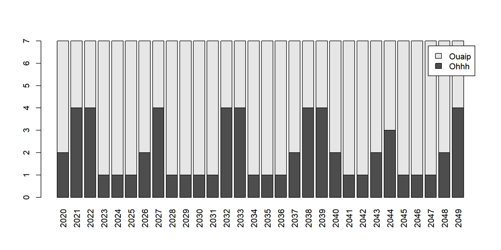

```r
barplot(t(jFeriesM), legend.text = TRUE, las = 3)
```

## `Date` et `POSIX`

Class “POSIXct” represents the (signed) number of seconds since the beginning of 1970 (in the UTC time zone) as a numeric vector.

## `Date` et `POSIX`

```r
dateHeure <- "27/12/2018 17:32:45"
as.POSIXct(dateHeure, format = "%d/%m/%Y %H:%M:%S")
```

```
## [1] "2018-12-27 17:32:45 CET"
```

# TD 01